# 3280 Project

# Stat 3280 Final Project

### 12/1/2025

# The Evolution of the Quarterback Position in the NFL

## Introduction

The National Football League (NFL) was founded 105 years ago, but despite its longevity, the game is still evolving at a fast pace. Whether you watch the sport or not, every year brings changes to how one thought the game should be played. One clear thing noticed in recent years, for example, is the higher prevalence of dual threat quarterbacks, players who are effective in both passing and running the ball. In this project, I will use data from the 2012 NFL season up until the 2024 season to look at how teams have changed their focus over the last 13 years. Specifically, I will be focusing on quarterbacks as they are considered “game managers” and the most influential part of a football team. In addition to seeing if quarterbacks as a whole have evolved, this project will analyze if this change is leading to better team performance. Although football is not a one position sport, teams rarely compete well with a sub-par quarterback and the best performing teams typically have what are considered the best quarterbacks.

## Questions to be Answered:

How has the quarterback position evolved in regards to passing versus running the ball?

What are the other relevant quarterback statistics that have seen changes in the last 13 years?

Have the quarterbacks who adapted their game to be more versatile seen more success within the NFL?

### Part 1: How has the quarterback position evolved in regards to passing versus running the ball?

#### Are Quarterbacks Running More?

The following visualization and all other ones include all regular season data (no playoffs) for quarterbacks that played at least eight games (half or more) and threw at least 100 pass attempts throughout the year. In this graph, years have been lumped into bins except for the most recent season for easier viewing. Each of the bins represents three years of data.

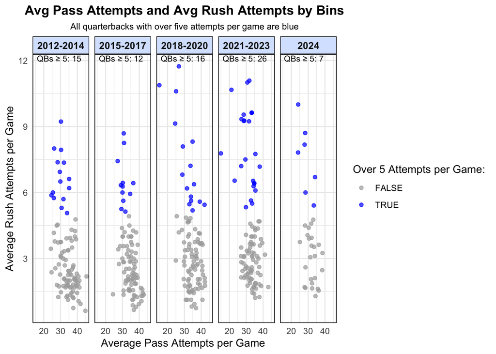

This first scatter plot illustrates the clear trend in quarterbacks rushing the ball more often. From 2012-2014, there were only 15 total quarterbacks in those three seasons that averaged over 5 attempts per game. That is an average of 5 per season. However, the years 2021-2023, had 26 quarterbacks that fit this criteria. It also becomes clear when looking at more rush attempts per game as well. It appears in the 2012-2014 and 2015-2017 years that there were only 5 instances of averaging over 7.5 attempts a game. This starkly contrasts 2024 where in that one year, there were four who achieved this.

Another way to look at all quarterbacks who hit a certain threshold is to view it dynamically. The metric used in the following is now average rushing yards per game and not rushing attempts. This visualization only includes the 2013-2024 season as to have four even bins of three seasons.

[figure not shown]

```javascript
var divElement = document.getElementById('viz1789432752052');                    var vizElement = divElement.getElementsByTagName('object')[0];                    if ( divElement.offsetWidth > 800 ) { vizElement.style.width='1000px';vizElement.style.height='827px';} else if ( divElement.offsetWidth > 500 ) { vizElement.style.width='1000px';vizElement.style.height='827px';} else { vizElement.style.width='100%';vizElement.style.height='777px';}                     var scriptElement = document.createElement('script');                    scriptElement.src = 'https://public.tableau.com/javascripts/api/viz_v1.js';                    vizElement.parentNode.insertBefore(scriptElement, vizElement);
```

While it is obvious to see trends towards what can be described as “rushing quarterbacks,” does that mean that they are passing the ball less? The prior graphs do not give a great indication of this so it is critical to see if passing is being replaced by rushing or if quarterbacks are being worked more as a whole.

#### Are Quarterbacks Passing the Ball Less then?

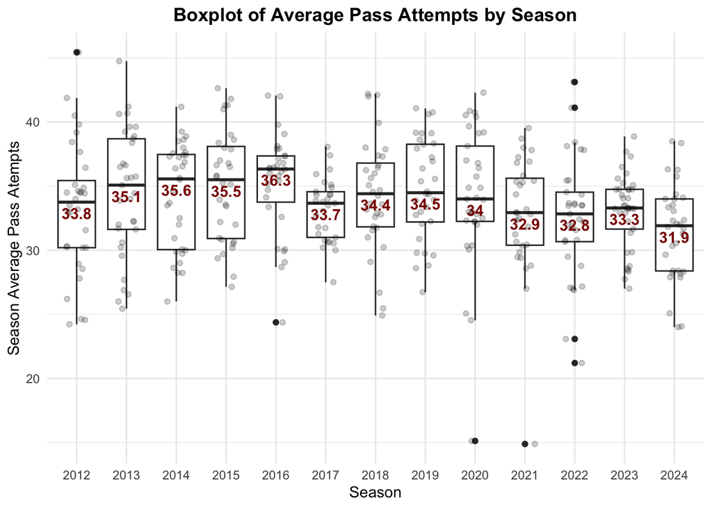

Attempting passes and completing passes are two very different things. Before drawing any conclusions about quarterbacks neglecting the pass, it is important to see if the reason for attempting less is because they are more accurate and throwing the ball further.

#### Are Quarterbacks Just More Accurate and Throwing Farther?

[interactive chart not shown]

| Season | Avg Yards/Game | Avg Completion % |
| --- | --- | --- |
| 2012 | 237.4 | 61.1 |
| 2013 | 247.0 | 61.5 |
| 2014 | 248.6 | 62.9 |
| 2015 | 257.7 | 63.3 |
| 2016 | 254.7 | 63.5 |
| 2017 | 235.1 | 62.7 |
| 2018 | 255.2 | 65.1 |
| 2019 | 255.4 | 64.3 |
| 2020 | 248.9 | 66.0 |
| 2021 | 235.8 | 64.9 |
| 2022 | 231.3 | 64.4 |
| 2023 | 228.7 | 64.6 |
| 2024 | 227.9 | 65.5 |

Using both the animated plot and the supplemental table, it illustrates how quarterbacks are throwing the ball less than they used to. When looking at the plot, it starts with 2012-2019 showing the majority of quarterbacks having 225-300 passing yards on average. From 2020-2024, one can see a shift where most situate to the 200-250 range. This is supported with the table which shows that from 2012-2021, the average passing yards per game was at least 235 (with 7 of 10 years being over 247) and then from 2022-2024 it is no higher than 232 with 2024 being only 227. However, quarterback accuracy has gone up. Completion percentages from 2017 and earlier are all below 63.5% and every completion percentage after 2017 is close to or above 65%.

With less passing yards but a higher accuracy, it bring into question if interceptions have therefore decreased in this span. Before delving into other assessments of quarterbacks changes that indirectly affect the pass and run game, this is an important statistic to check.

### Part 2: What are the other relevant quarterback statistics that have seen changes in the last 13 years?

#### If Passing Yards Are Down, Does That Mean Interceptions Are As Well?

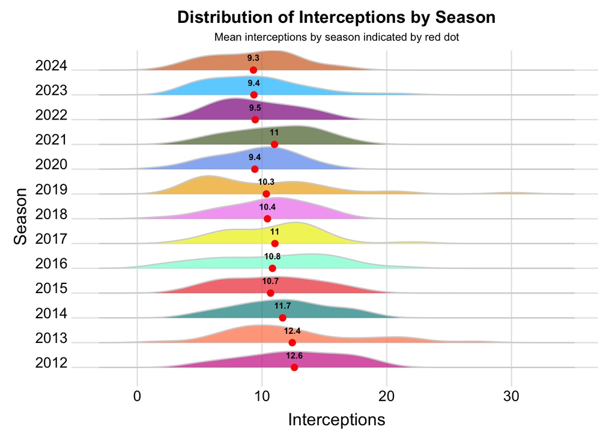

In this density ridge plot, it can be seen how the distribution of interceptions has changed significantly from 2012 up until the most recent NFL season. In the early 2010s, the mean amount of interceptions was hovering between 11 and 12.5. In more recent years such as 2022-2024, not a single season had a mean over 10. The ridges also extend out with higher density further to the right in the earlier years tested. This chart illustrates that along with quarterbacks being more accurate, they also do a better job of not turning the ball over.

In addition to information about quarterback passing attempts, yards, and interceptions, there is data about how many times they threw from the shotgun (started farther away from the line of scrimmage) and how many times they dropped back after snapping the ball. It is important to see if there is a connection between snapping the ball in a different position and potentially running it.

#### Does Starting in the Shotgun Position Lead to More Running Plays?

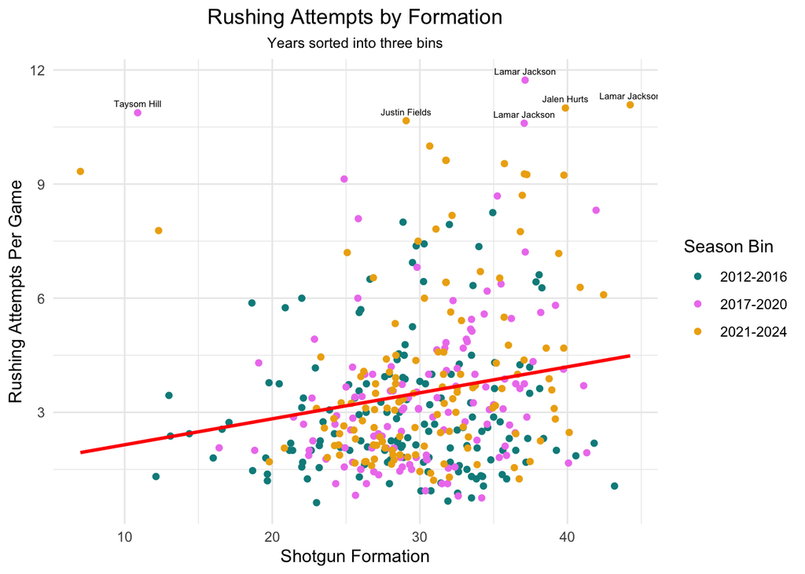

This scatter plot conveys the positive relationship between quarterbacks going in the shotgun formation and rush attempts in the game. This is not completely surprising because by snapping the ball from further back, the quarterback is given more time to decide if throwing is actually the best option. It also can give them an edge if they are attempting to run diagonally instead of straight forward. This visualization highlights the names of outliers who on average, rush at least 10 times per game if one is interested in that data.

One final and common statistic for a quarterback is the amount of times they drop back after snapping the ball. This means that after catching the ball, they take a few steps into the pocket where they separate themselves from the defense before ultimately throwing or running the ball. However, it is a statistic typically indicative of a pass. This is because the quarterback immediately moves backwards after getting the ball and it takes valuable time for them to step back which leads them with less opportunities to escape an oncoming defender.

#### If Quarterbacks are Throwing the Ball Less, Does that Mean Less Dropbacks?

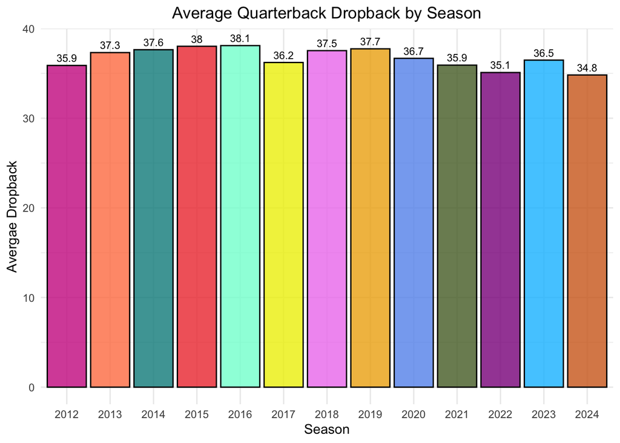

Based on this data, it seems as if there is no trend between quarterback dropback and season. While the 2024 season did have the lowest average dropback rate, it was not significantly lower than any other year. The year prior also has a rate that matches all others which makes it clear that without more years of data, it is not indicative of a downward trend in this statistic.

With the conclusion of this graph, it brings up the final question, have the quarterbacks who adapted their game seen success within the NFL? This will help tie in all of the visualizations and convey if the trends seen actually do make a difference in making the playoffs.

### Part 3: Have the quarterbacks who adapted their game to be more versatile seen more success within the NFL?

As a note, if a quarterback played more than eight games in the season and that team made the playoffs while they were hurt, it includes them. If no quarterback played at least eight games for a team and they made the playoffs, then they are not included. For example, no quarterback for the Washington Football Team in 2020 started at least eight games this season so none of their data is included in the visualization despite them making the playoffs. However, the 2017 Philadelphia Eagles had their quarterback, Carson Wentz, play 13 games and lead them to the playoffs. He ended up getting hurt and missed the final three games of the season and their playoff games. In this visualization, Carson Wentz would still be considered making the playoffs since he started over eight games that season.

[interactive chart not shown]

This animated visual compares average rushing and passing yards for quarterbacks who made and did not make the playoffs. Through this graph, it becomes clear that quarterbacks who rushed for more yards typically have higher rates of making the playoffs but it was less obvious. There was not a single threshold that was noticeable where if a quarterback ran for a certain amount of yards, they would make the postseason. For example, the 2021 Baltimore Ravens missed the playoffs with their quarterback averaging over 10 more rushing yards per game than the next highest quarterback. However, if a quarterback averages over ~40 rushing yards per game, they made the playoffs about half of the time as opposed to the 37.5% or 43.75% chance if there are 12 or 14 teams in the postseason.

The prior graph illustrated average rushing yards and average passing yards but not pass attempts and rush attempts. In the following shiny app, there is a scatter plot of average pass attempt and rush attempts. There is also the ability to filter the data based on specific seasons, emphasize specific quarterbacks, filter whether the team made the postseason, and a customizable trend line. There is also a summary stat at the top that updates with the other filters. Finally, a line graph of average rush attempts and season is shown. This can be customized to be turned into a bar chart and has the ability to toggle between it showing the mean, median, and total.

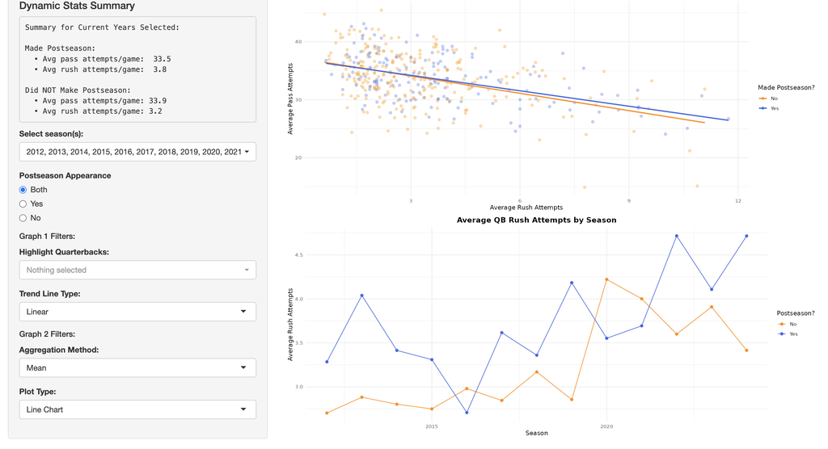

Click on the graph or click this link to adjust filters: https://alexheyman.shinyapps.io/Stat3280Shiny1/

Since the prior animation did not give conclusive evidence on if quarterbacks rushing or passing more leads to performance, it is critical to look at a probability plot to see if better correlations can be illustrated.

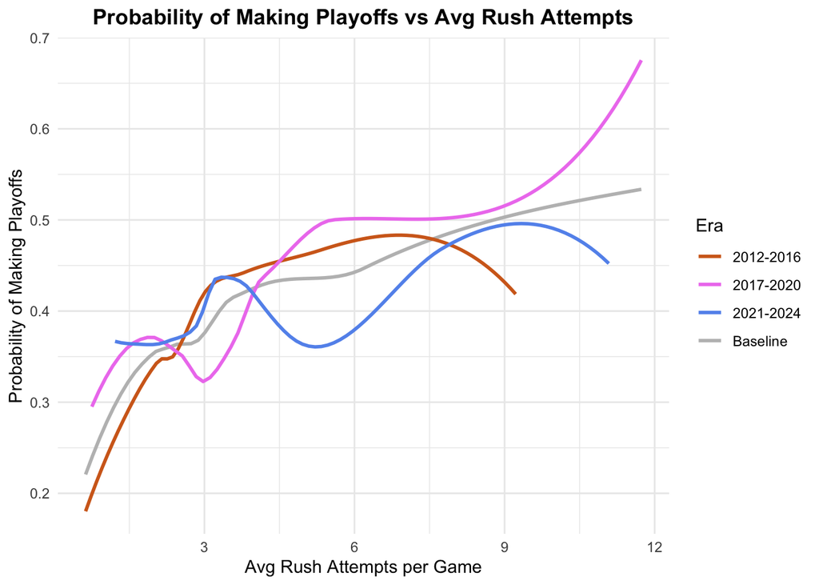

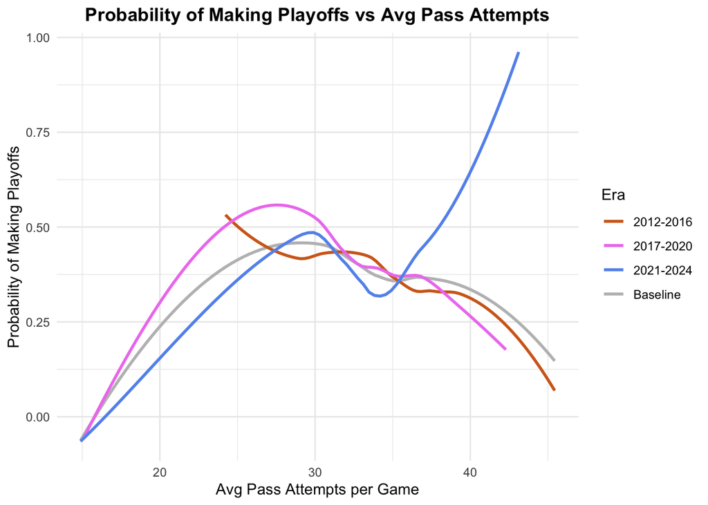

Both of these probability plots give important insight into the chances of making the playoffs based on average rush and pass attempts.

The last pieces of data to look at regarding playoff appearances are efficiency metrics. In the following Shiny app, one can toggle between four of these and also plot it against quarterback workload (average pass attempts) or by season.

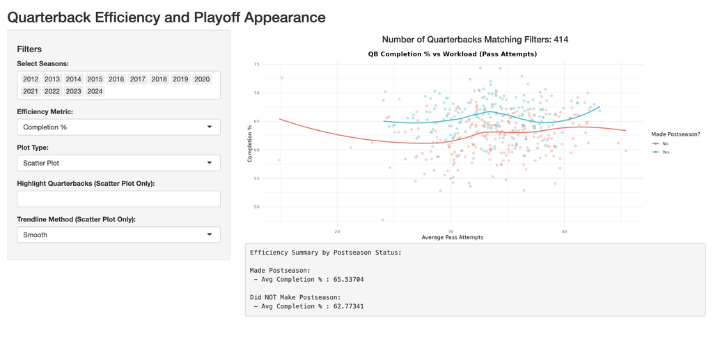

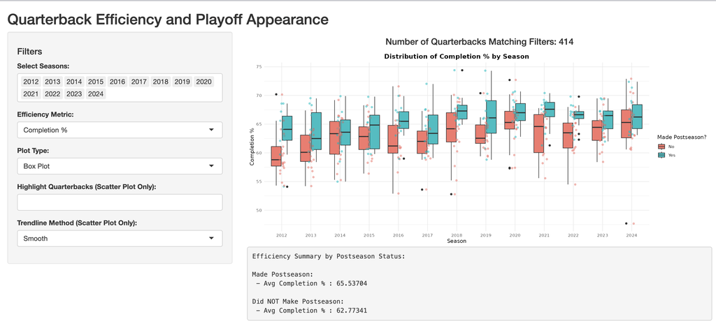

Click on either of the graphs or click this link to adjust filters:https://alexheyman.shinyapps.io/project/

When looking at the scatter plot part of the Shiny app, one can see how quarterbacks with a higher completion percent, passing yards per attempt, and touchdown to interception ratio were more likely to make the playoffs. This visualization makes it appear as if average pass attempts has little to nothing to do with making the playoffs compared to these efficiencies. The only one that is widely different is rushing yards per attempt. In this plot, rushing yards per attempt and average pass attempts had a negative relationship for both the making and not making postseason lines.

The box plot revealed similar insight based on year. For completion percent, passing yards per attempt, and touchdown to interception ratio, they all saw higher medians and box sizes for quarterbacks who made the playoffs versus those who did not. There was not a single case where this principle strayed for those three efficiency metrics. For rushing yards per attempt, the data was pretty split. For five out of thirteen years, the median rushing yards per attempt was higher for quarterbacks who made the playoffs compared to those who did not. This insight, paired with the scatter plot version, reveal that even though prior visualizations showed that quarterbacks who rushed more are more likely to make the playoffs, rushing yards per attempt is not an effective metric to predict making the postseason.

### Conclusion

Tying everything together conveys how important quarterbacks are to an entire football team because of how influential their statistics are in a team’s likelihood of making the playoffs, Though there have been trends in quarterbacks adapting their game leading to season success, once enough players change how they play, then everyone is on an even playing field. It is interesting to look at how football is evolving and realize that every new year can lead to a period of change.